# R Notebook

1. Definir la semilla a utilizar, que corresponde a los primeros cinco dígitos del RUN del integrante de mayor edad del equipo.

```r
set.seed(20426)
knitr::opts_chunk$set(cache = T)
library(dplyr)
library(car)
library(caret)
library(leaps)
library(pROC)
library(ggpubr)
library(lmtest)
```

2. Seleccionar una muestra de 100 personas, asegurando que la mitad tenga estado nutricional “sobrepeso” y la otra mitad “no sobrepeso”.

```r
# cargar datos
datos <- read.csv2("EP09 Datos.csv")

# Calculo IMC
peso <- datos[["Weight"]]
estatura <- datos[["Height"]] / 100
IMC <- round(peso / (estatura**2), 2)

datos <- cbind(datos,IMC)

# Si el IMC >= 25.0 -> 1
# Si el IMC < 25.0, -> 0
EN <- case_when(IMC >= 25.0 ~ 1, IMC < 25.0 ~ 0, TRUE ~ IMC)

# Combina los datos originales con la nueva variable
datos <- cbind(datos, EN)

# Generacion de muestras aleatorias para EN = 1 y EN = 0
temp1 <- datos %>% filter(EN == 1) %>% sample_n(50, replace = FALSE)
temp2 <- datos %>% filter(EN == 0) %>% sample_n(50, replace = FALSE)

# Combinacion de las muestras
muestra <- rbind(temp1, temp2)
head(muestra)
```

|  | Biacromial.diameter | Biiliac.diameter | Bitrochanteric.diameter | Chest.depth | Chest.diameter | Elbows.diameter | Wrists.diameter | Knees.diameter | Ankles.diameter | Shoulder.Girth | Chest.Girth | Waist.Girth | Navel.Girth | Hip.Girth | Thigh.Girth | Bicep.Girth | Forearm.Girth | Knee.Girth | Calf.Maximum.Girth | Ankle.Minimum.Girth | Wrist.Minimum.Girth | Age | Weight | Height | Gender | IMC | EN |
| --- | --- | --- | --- | --- | --- | --- | --- | --- | --- | --- | --- | --- | --- | --- | --- | --- | --- | --- | --- | --- | --- | --- | --- | --- | --- | --- | --- |
| 1 | 43.8 | 30.4 | 34.9 | 24.0 | 33.3 | 15.4 | 11.6 | 17.8 | 14.6 | 129.2 | 111.5 | 100.5 | 107.3 | 109.5 | 61.8 | 37.4 | 31.6 | 41.0 | 39.7 | 25.4 | 18.4 | 45 | 102.3 | 185.4 | 1 | 29.76 | 1 |
| 2 | 38.5 | 26.6 | 34.0 | 22.3 | 26.6 | 13.8 | 10.7 | 20.0 | 15.5 | 114.2 | 92.3 | 78.0 | 100.9 | 106.9 | 65.5 | 31.7 | 26.3 | 38.5 | 39.7 | 22.8 | 15.6 | 24 | 75.9 | 172.7 | 0 | 25.45 | 1 |
| 3 | 40.3 | 28.0 | 32.0 | 20.9 | 31.7 | 14.8 | 10.6 | 19.4 | 15.0 | 126.7 | 109.1 | 85.9 | 90.4 | 100.9 | 61.3 | 40.1 | 30.0 | 36.8 | 38.6 | 21.9 | 16.4 | 25 | 87.1 | 182.2 | 1 | 26.24 | 1 |
| 4 | 38.2 | 30.0 | 35.5 | 19.4 | 26.7 | 12.6 | 10.8 | 19.5 | 13.6 | 102.8 | 92.2 | 83.0 | 101.4 | 108.1 | 65.0 | 29.8 | 24.6 | 38.1 | 37.8 | 20.7 | 16.6 | 47 | 75.7 | 174.0 | 0 | 25.00 | 1 |
| 5 | 42.3 | 30.2 | 34.4 | 25.4 | 32.2 | 15.2 | 10.7 | 18.8 | 14.8 | 125.3 | 114.0 | 98.5 | 103.8 | 108.1 | 61.3 | 37.2 | 31.4 | 41.9 | 42.1 | 26.4 | 17.9 | 29 | 96.8 | 177.8 | 1 | 30.62 | 1 |
| 6 | 35.6 | 29.9 | 33.5 | 18.2 | 24.9 | 13.2 | 11.0 | 19.2 | 13.8 | 98.9 | 93.0 | 80.5 | 98.8 | 107.2 | 63.0 | 34.1 | 27.6 | 38.8 | 38.2 | 22.2 | 16.3 | 41 | 77.3 | 170.2 | 0 | 26.68 | 1 |

3. Usando las herramientas del paquete leaps, realizar una búsqueda exhaustiva para seleccionar entre dos y ocho predictores que ayuden a estimar la variable Peso (Weight), obviamente sin considerar las nuevas variables IMC ni EN, y luego utilizar las funciones del paquete caret para construir un modelo de regresión lineal múltiple con los predictores escogidos y evaluarlo usando bootstrapping.

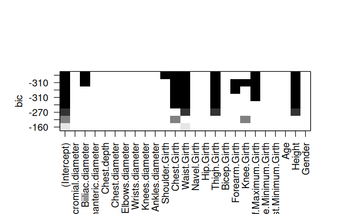

```r
variables <- colnames(muestra)

# Copia del dataframe muestra
muestra_rlm <- data.frame(muestra)

# Eliminacion de las variables de respuesta
muestra_rlm[['EN']] <- NULL
muestra_rlm[['IMC']] <- NULL

# Para RLM seleccionar mejores predictores usando el método de todos los subconjuntos.
maxPredictores <- 8
predictores_potenciales <- regsubsets(Weight ~ . , data = muestra_rlm, method = "exhaustive", nbest = 1,nvmax = maxPredictores)
plot(predictores_potenciales)
```

El método de todos los conjuntos revela que el mejor modelo incluye los siguientes predictores: ‘Biiliac.diameter’, ‘Shoulder.girth’, ‘Chest.girth’, ‘Waist.girth’, ‘Thigh.girth’, ‘Calf.maximum.girth’ y ‘Height’. Debido a que el modelo generado a partir de estos predictores es el que presenta menos BIC entre los subconjuntos de predictores.

```r
# Selección de los datos de entrenamiento y prueba
n_rlm <- nrow(muestra_rlm)
# 0.8 ya que 80% para entrenamiento y 20% para prueba
n_entrenamiento_rlm <- floor(0.8 * n_rlm)
# Datos aleatorios
m_rlm <- sample.int(n = n_rlm, size = n_entrenamiento_rlm, replace = FALSE)
# Datos de entrenamiento
entrenamiento_rlm <- muestra_rlm[m_rlm, ]
# Datos de prueba
prueba_rlm <-  muestra_rlm[-m_rlm, ]

# Entrenamiento del modelo
rlm <- train(Weight ~ Biiliac.diameter + Shoulder.Girth + Chest.Girth + Waist.Girth + Thigh.Girth  + Calf.Maximum.Girth + Height , data = muestra_rlm,                    method = "lm" , trControl = trainControl(method = "boot"))
```

```r
# Error cuadrático medio del modelo de entrenamiento
predict_entrenamiento <- predict(rlm, entrenamiento_rlm)
err_entrenamiento_rlm <- entrenamiento_rlm[["Weight"]] - predict_entrenamiento
mse_entrenamiento_rlm <- mean(err_entrenamiento_rlm)**2
cat('MSE Entrenamiento = ', mse_entrenamiento_rlm, "\n\n")
```

```
MSE Entrenamiento =  0.05485307
```

```r
# Error cuadrático medio del modelo de prueba
predict_prueba <- predict(rlm, prueba_rlm)
err_prueba_rlm <- prueba_rlm[["Weight"]] - predict_prueba
mse_prueba_rlm <- mean(err_prueba_rlm)**2
cat('MSE Prueba = ', mse_prueba_rlm, "\n\n")
```

```
MSE Prueba =  0.8776492
```

Podemos observar que el error presentado por el modelo para los casos de entrenamiento y prueba presenta una variación significativa entre ellos. Sin embargo, si observamos la variable de respuesta que se intenta predecir, vemos que varía en un rango de aproximadamente 160. Por lo tanto, podemos concluir que el modelo puede ser generalizable en relación a las predicciones entregadas.

4. Haciendo un poco de investigación sobre el paquete caret, en particular cómo hacer Recursive Feature Elimination (RFE), construir un modelo de regresión lineal múltiple para predecir la variable IMC que incluya entre 10 y 20 predictores, seleccionando el conjunto de variables que maximice R2 y que use cinco repeticiones de validación cruzada de cinco pliegues para evitar el sobreajuste (obviamente no se debe considerar las variables Peso, Estatura ni estado nutricional –Weight, Height, EN respectivamente).

```r
# Creacion del dataframe muestra
muestra_imc <- data.frame(muestra)
# Eliminacion de las variables
muestra_imc[['Weight']] <-  NULL
muestra_imc[['Height']] <- NULL
muestra_imc[['EN']] <- NULL

#mostrar las primeras 5 filas del dataframe
head(muestra_imc)
```

|  | Biacromial.diameter | Biiliac.diameter | Bitrochanteric.diameter | Chest.depth | Chest.diameter | Elbows.diameter | Wrists.diameter | Knees.diameter | Ankles.diameter | Shoulder.Girth | Chest.Girth | Waist.Girth | Navel.Girth | Hip.Girth | Thigh.Girth | Bicep.Girth | Forearm.Girth | Knee.Girth | Calf.Maximum.Girth | Ankle.Minimum.Girth | Wrist.Minimum.Girth | Age | Gender | IMC |
| --- | --- | --- | --- | --- | --- | --- | --- | --- | --- | --- | --- | --- | --- | --- | --- | --- | --- | --- | --- | --- | --- | --- | --- | --- |
| 1 | 43.8 | 30.4 | 34.9 | 24.0 | 33.3 | 15.4 | 11.6 | 17.8 | 14.6 | 129.2 | 111.5 | 100.5 | 107.3 | 109.5 | 61.8 | 37.4 | 31.6 | 41.0 | 39.7 | 25.4 | 18.4 | 45 | 1 | 29.76 |
| 2 | 38.5 | 26.6 | 34.0 | 22.3 | 26.6 | 13.8 | 10.7 | 20.0 | 15.5 | 114.2 | 92.3 | 78.0 | 100.9 | 106.9 | 65.5 | 31.7 | 26.3 | 38.5 | 39.7 | 22.8 | 15.6 | 24 | 0 | 25.45 |
| 3 | 40.3 | 28.0 | 32.0 | 20.9 | 31.7 | 14.8 | 10.6 | 19.4 | 15.0 | 126.7 | 109.1 | 85.9 | 90.4 | 100.9 | 61.3 | 40.1 | 30.0 | 36.8 | 38.6 | 21.9 | 16.4 | 25 | 1 | 26.24 |
| 4 | 38.2 | 30.0 | 35.5 | 19.4 | 26.7 | 12.6 | 10.8 | 19.5 | 13.6 | 102.8 | 92.2 | 83.0 | 101.4 | 108.1 | 65.0 | 29.8 | 24.6 | 38.1 | 37.8 | 20.7 | 16.6 | 47 | 0 | 25.00 |
| 5 | 42.3 | 30.2 | 34.4 | 25.4 | 32.2 | 15.2 | 10.7 | 18.8 | 14.8 | 125.3 | 114.0 | 98.5 | 103.8 | 108.1 | 61.3 | 37.2 | 31.4 | 41.9 | 42.1 | 26.4 | 17.9 | 29 | 1 | 30.62 |
| 6 | 35.6 | 29.9 | 33.5 | 18.2 | 24.9 | 13.2 | 11.0 | 19.2 | 13.8 | 98.9 | 93.0 | 80.5 | 98.8 | 107.2 | 63.0 | 34.1 | 27.6 | 38.8 | 38.2 | 22.2 | 16.3 | 41 | 0 | 26.68 |

```r
# Selección de los datos de entrenamiento y prueba
n_imc <- nrow(muestra_imc)
n_entrenamiento_imc <- floor(0.8 * n_imc)
m_imc <- sample.int(n = n_imc, size = n_entrenamiento_imc, replace = FALSE)
entrenamiento_imc_x <- muestra_imc[m_imc, ]
prueba_imc_x <-  muestra_imc[-m_imc, ]

# Datos de entrenamiento
entrenamiento_imc_y <- entrenamiento_imc_x[ , ncol(entrenamiento_imc_x)]
entrenamiento_imc_x[['IMC']] <- NULL
# Datos de prueba
prueba_imc_y <- prueba_imc_x[ , ncol(prueba_imc_x)]
prueba_imc_x[['IMC']] <- NULL
```

El método RFE (Recursive Feature Elimination) utiliza los siguientes parámetros: 2 dataframes, uno con las variables X (predictores) a elegir para encontrar la variable Y (Respuesta), sizes para encontrar el mejor subconjunto dentro de lo establecido en el parámetro (en este caso elegir el mejor subconjunto de entre 10 a 20 predictores), metric que en simples palabras es la métrica que la función utilizará para encontrar el mejor modelo con el subconjunto de predictores (Existen varias métricas como RMSE, RSquared…), maximize que es si se busca maximizar o, por el contrario, minimizar la métrica señalada en el parámetro anterior, y por último rfeControl, que sirve para controlar el modelo creado. Si vemos en retrospectiva, la función rfe al buscar los subconjuntos realiza el llamado a la función fit de lmFuncs, que es la función dentro del parámetro rfeControl, y dentro de fit realiza el llamado a lm(), el cual utilizará los siguientes parámetros obtenidos a través de rfeControl, como method, repeats, para la creación del modelo.

```r
set.seed(20426)
# variables de control
control <- rfeControl(functions = lmFuncs , #  lmFuncs para modelos lineales
                      method = "repeatedcv", # Validacion cruzada con k iteraciones
                      repeats = 5, # 5
                      number = 5, # k = 5
                      returnResamp = "all",
                      saveDetails = TRUE
                      )

# Utilización del método RFE, que de manera recursiva busca los mejores Predictores para la variable Y (respuesta) con el conjunto de variables X (Predictores).
modelo_imc <- rfe(x = entrenamiento_imc_x,  # Predictores
                       y = entrenamiento_imc_y, # Respuesta
                       sizes = c(10:20),  #Subconjuntos de predictores a encontrar
                       rfeControl = control, # variables de control
                       metric = "Rsquared", # Metrica a utilizar
                       maximize = TRUE) # Maximizar la metrica utilizada

# Prediccion del modelo
predictors(modelo_imc)
```

```
 [1] "Gender"                  "Forearm.Girth"           "Ankles.diameter"
 [4] "Wrists.diameter"         "Knees.diameter"          "Elbows.diameter"
 [7] "Wrist.Minimum.Girth"     "Biacromial.diameter"     "Knee.Girth"
[10] "Calf.Maximum.Girth"      "Biiliac.diameter"        "Bicep.Girth"
[13] "Ankle.Minimum.Girth"     "Shoulder.Girth"          "Thigh.Girth"
[16] "Chest.diameter"          "Waist.Girth"             "Chest.depth"
[19] "Bitrochanteric.diameter"
```

```r
print(modelo_imc)
```

```
Recursive feature selection

Outer resampling method: Cross-Validated (5 fold, repeated 5 times)

Resampling performance over subset size:
```

|  | Variables | RMSE | Rsquared | MAE | RMSESD | RsquaredSD | MAESD | Selected |
| --- | --- | --- | --- | --- | --- | --- | --- | --- |
| 1 | 10 | 2.016 | 0.6390 | 1.646 | 0.3847 | 0.14525 | 0.3387 |  |
| 2 | 11 | 1.932 | 0.6707 | 1.575 | 0.3523 | 0.11953 | 0.3225 |  |
| 3 | 12 | 1.802 | 0.7125 | 1.482 | 0.3563 | 0.11214 | 0.3459 |  |
| 4 | 13 | 1.671 | 0.7635 | 1.359 | 0.3459 | 0.09026 | 0.3438 |  |
| 5 | 14 | 1.524 | 0.8016 | 1.240 | 0.3124 | 0.08314 | 0.3042 |  |
| 6 | 15 | 1.479 | 0.8129 | 1.197 | 0.2975 | 0.08664 | 0.2822 |  |
| 7 | 16 | 1.473 | 0.8140 | 1.183 | 0.3161 | 0.09878 | 0.2898 |  |
| 8 | 17 | 1.484 | 0.8112 | 1.190 | 0.3154 | 0.09849 | 0.2820 |  |
| 9 | 18 | 1.447 | 0.8215 | 1.161 | 0.2470 | 0.07557 | 0.2308 |  |
| 10 | 19 | 1.436 | 0.8254 | 1.149 | 0.2248 | 0.06649 | 0.2064 | * |

[output cut: 2 more lines]

```
The top 5 variables (out of 19):
   Gender, Forearm.Girth, Ankles.diameter, Wrists.diameter, Knees.diameter
```

Como se observa en el dataframe de modelo_imc, el modelo seleccionado por el método RFE es el que utiliza 19 variables predictoras en el modelo, con un RSquared de 0.8254.

```r
modelo_imc$fit # llamada a lm para crear el modelo con las variables predictoras seleccionadas por el método rfe
```

```
Call:
lm(formula = y ~ ., data = tmp)

Coefficients:
            (Intercept)                   Gender            Forearm.Girth
               -9.56146                 -1.86376                  0.52816
        Ankles.diameter          Wrists.diameter           Knees.diameter
               -0.39154                  0.18289                  0.39365
        Elbows.diameter      Wrist.Minimum.Girth      Biacromial.diameter
               -0.12152                 -0.28526                 -0.29766
             Knee.Girth       Calf.Maximum.Girth         Biiliac.diameter
               -0.22525                  0.19042                  0.21922
            Bicep.Girth      Ankle.Minimum.Girth           Shoulder.Girth
               -0.08072                 -0.07321                  0.15613
            Thigh.Girth           Chest.diameter              Waist.Girth
                0.10058                 -0.02259                  0.17778
            Chest.depth  Bitrochanteric.diameter
               -0.01170                 -0.05711
```

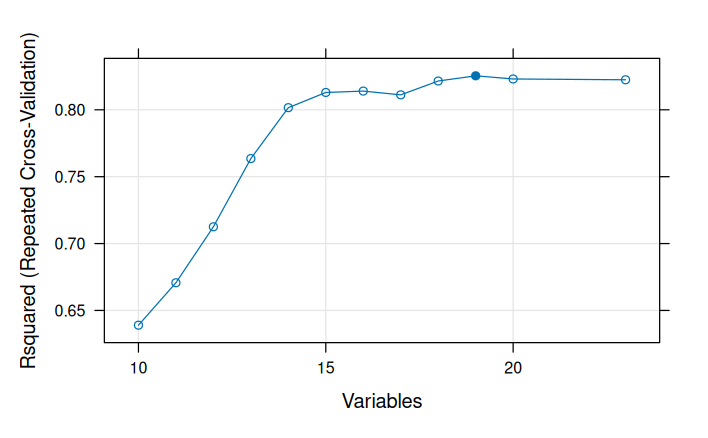

```r
plot(modelo_imc, type = c('g','o')) # Grafico para ver el cambio de la metrica respecto a las variables ingresadas al modelo
```

En el gráfico se observa la metrica RSquared y los cambios generados por la cantidad de variables dentro del modelo predictivo Si nos fijamos detenidamente, podemos ver que el modelo con 19 predictores es el que tiene el mayor valor de RSquared, el cual fue seleccionado mediante el método RFE. Asimismo, podemos observar que a medida que se reducen las variables predictoras, el valor de RSquared disminuye.

```r
# Muestra del error predicho en la prueba y en el entrenamiento.
rlm_prueba_imc <- postResample(predict(modelo_imc, prueba_imc_x), prueba_imc_y)
cat('Error predicho en prueba \n')
```

```
Error predicho en prueba
```

```r
print(rlm_prueba_imc)
```

```
    RMSE Rsquared      MAE
1.847122 0.680720 1.401732
```

```r
cat('\n\n')
```

```r
cat('Error predicho en entrenamiento\n' )
```

```
Error predicho en entrenamiento
```

```r
cat('RMSE:',modelo_imc$results[10,]$RMSE)
```

```
RMSE: 1.435959
```

```r
cat(', Rsquared: ',modelo_imc$results[10,]$Rsquared)
```

```
, Rsquared:  0.8254084
```

```r
cat(', MAE: ',modelo_imc$results[10,]$MAE)
```

```
, MAE:  1.149246
```

5. Usando RFE, construir un modelo de regresión logística múltiple para la variable EN que incluya el conjunto, de entre dos y seis, predictores que entregue la mejor curva ROC y que utilice validación cruzada dejando uno fuera para evitar el sobreajuste (obviamente no se debe considerar las variables Peso, Estatura –Weight y Height respectivamente– ni IMC).

```r
set.seed(20426)
# Creacion del dataframe muestra
muestra_en <- data.frame(muestra)

# eliminacion de las variables
muestra_en[['Weight']] <-  NULL
muestra_en[['Height']] <- NULL
muestra_en[['IMC']] <- NULL
#muestra_en[['Elbows.diameter']] <- NULL
#muestra_en[['Age']] <- NULL
#muestra_en[['Gender']] <- NULL

# Se modifica la variable EN de numeric a factor, para propositos de modelo glm
EN <- as.factor(muestra_en[['EN']])
# Eliminacion de la variable EN
muestra_en[['EN']] <- NULL
# Agregacion de la nueva variable EN
muestra_en <- cbind(muestra_en, EN)
# Reordenamiento de las filas para obtener una muestra aleatoria
muestra_en <- muestra_en[sample(nrow(muestra_en)), ]

head(muestra_en)
```

|  | Biacromial.diameter | Biiliac.diameter | Bitrochanteric.diameter | Chest.depth | Chest.diameter | Elbows.diameter | Wrists.diameter | Knees.diameter | Ankles.diameter | Shoulder.Girth | Chest.Girth | Waist.Girth | Navel.Girth | Hip.Girth | Thigh.Girth | Bicep.Girth | Forearm.Girth | Knee.Girth | Calf.Maximum.Girth | Ankle.Minimum.Girth | Wrist.Minimum.Girth | Age | Gender | EN |
| --- | --- | --- | --- | --- | --- | --- | --- | --- | --- | --- | --- | --- | --- | --- | --- | --- | --- | --- | --- | --- | --- | --- | --- | --- |
| 41 | 41.1 | 26.8 | 32.4 | 20.2 | 31.1 | 14.4 | 11.8 | 20.4 | 15.2 | 120.0 | 101.0 | 82.0 | 82.0 | 98.0 | 59.0 | 35.4 | 29.0 | 38.0 | 42.0 | 23.6 | 17.5 | 34 | 1 | 1 |
| 68 | 40.1 | 28.2 | 33.3 | 20.9 | 31.7 | 13.9 | 10.9 | 19.7 | 14.1 | 115.1 | 97.5 | 83.2 | 82.9 | 95.0 | 57.3 | 33.4 | 28.8 | 37.0 | 37.3 | 21.9 | 16.9 | 28 | 1 | 0 |
| 56 | 35.1 | 26.6 | 29.2 | 17.0 | 24.4 | 11.8 | 9.4 | 17.0 | 12.2 | 94.4 | 82.5 | 65.6 | 81.8 | 92.8 | 56.2 | 28.8 | 24.7 | 33.0 | 34.6 | 21.7 | 15.8 | 32 | 0 | 0 |
| 53 | 41.6 | 27.5 | 32.0 | 18.1 | 29.5 | 13.8 | 10.7 | 19.0 | 13.9 | 112.5 | 90.9 | 80.3 | 80.8 | 92.8 | 53.9 | 32.5 | 28.0 | 36.5 | 35.0 | 21.0 | 16.4 | 37 | 1 | 0 |
| 5 | 42.3 | 30.2 | 34.4 | 25.4 | 32.2 | 15.2 | 10.7 | 18.8 | 14.8 | 125.3 | 114.0 | 98.5 | 103.8 | 108.1 | 61.3 | 37.2 | 31.4 | 41.9 | 42.1 | 26.4 | 17.9 | 29 | 1 | 1 |
| 80 | 36.2 | 27.5 | 30.4 | 18.7 | 28.0 | 13.6 | 10.8 | 19.0 | 15.4 | 111.2 | 91.2 | 78.8 | 78.0 | 93.2 | 55.8 | 31.9 | 27.4 | 36.4 | 35.1 | 23.0 | 16.8 | 22 | 1 | 0 |

```r
set.seed(20426)
# Selección de los datos de entrenamiento y prueba
n_en <- nrow(muestra_en)
n_entrenamiento_en <- floor(0.8 * n_en)
m_en <- sample.int(n = n_en, size = n_entrenamiento_en, replace = FALSE)
entrenamiento_en_x <- muestra_en[m_en, ]
prueba_en_x <-  muestra_en[-m_en, ]

# Datos de entrenamiento
entrenamiento_en_y <- entrenamiento_en_x[ , ncol(entrenamiento_en_x)]
# Eliminacion de la variable de respuesta
entrenamiento_en_x[['EN']] <- NULL

# Datos de prueba
prueba_en_y <- prueba_en_x[ , ncol(prueba_en_x)]
# Eliminacion de la variable de respuesta
prueba_en_x[['EN']] <- NULL
```

```r
# Utilizando la funcion rfe
myFuncs <- lrFuncs

# Modificación de la función de ajuste
myFuncs$fit <- function(x, y, first, last, resample = FALSE, ...) {
  # Imprime los nombres de las variables que se están utilizando
  #
  #cat("Variables en esta iteración:\n")
  #print(names(x))
  #cat("\n")

  # Llama a la función de ajuste original con los argumentos proporcionados
    tmp <- if (is.data.frame(x))
        x
    else as.data.frame(x, stringsAsFactors = TRUE)
    tmp$Class <- y
    glm(Class ~ ., data = tmp, family = "binomial")
}


myFuncs$summary <- twoClassSummary # twoClass para que RFE utiliza metricas correspondientes a modelo Logistico
controlGlm <- rfeControl(functions = myFuncs , # MyFuncs utiliza la funcion lrFuncs para modelos logisticos
                      method = "LOOCV") # Validación cruzada dejando uno fuera

trainctrl <- trainControl(classProbs = TRUE,
                           summaryFunction = twoClassSummary)

glm_predictores <- rfe(x = entrenamiento_en_x,
                       y = entrenamiento_en_y,
                       sizes = c(2:6),
                       rfeControl = controlGlm,
                       metric = "ROC",
                       maximize = TRUE,
                       trControl = trainctrl)
```

[output not shown]

Los warnings se pueden explicar debido a que RFE funciona recursivamente, y al siempre empezar la iteración con el subconjunto completo (23 variables), es muy probable que dentro de este subconjunto existan predictores correlacionados entre sí, por lo cual se genera el warning de convergencia. No obstante, es importante mencionar que estos warnings se pueden pasar por alto debido a que solo ocurren en el primer subconjunto (y tal vez en el segundo si se dan las variables correctas), pero no en los últimos o en el subconjunto seleccionado por el RFE que estamos buscando utilizar.

```r
#predictors(glm)
print(glm_predictores)
```

```
Recursive feature selection

Outer resampling method: Leave-One-Out Cross-Validation

Resampling performance over subset size:
```

|  | Variables | ROC | Sens | Spec | Selected |
| --- | --- | --- | --- | --- | --- |
| 1 | 2 | 0.9150 | 0.725 | 0.875 |  |
| 2 | 3 | 0.9219 | 0.775 | 0.775 |  |
| 3 | 4 | 0.9644 | 0.900 | 0.825 |  |
| 4 | 5 | 0.9850 | 0.925 | 0.900 |  |
| 5 | 6 | 0.9725 | 0.950 | 0.875 |  |
| 6 | 23 | 0.9962 | 0.950 | 1.000 | * |

```
The top 5 variables (out of 23):
   Chest.diameter, Waist.Girth, Calf.Maximum.Girth, Knee.Girth, Thigh.Girth
```

```r
print(summary(glm_predictores$fit))
```

```
Call:
glm(formula = Class ~ ., family = "binomial", data = tmp)

Coefficients:
                          Estimate Std. Error z value Pr(>|z|)
(Intercept)             -5.867e+02  2.950e+06       0        1
Chest.diameter          -1.477e+01  3.251e+04       0        1
Waist.Girth              3.445e+00  1.945e+04       0        1
Calf.Maximum.Girth       8.833e+00  6.397e+04       0        1
Knee.Girth              -7.048e+00  4.674e+04       0        1
Thigh.Girth              2.864e+00  2.676e+04       0        1
Knees.diameter           1.056e+01  1.089e+05       0        1
Chest.Girth              2.098e+00  2.192e+04       0        1
Bicep.Girth              5.001e+00  5.570e+04       0        1
Shoulder.Girth           1.744e+00  2.044e+04       0        1
Bitrochanteric.diameter  5.829e+00  7.759e+04       0        1
Navel.Girth             -9.214e-01  1.291e+04       0        1
Ankles.diameter         -6.856e+00  9.936e+04       0        1
Chest.depth             -5.047e+00  1.114e+05       0        1
Biacromial.diameter     -2.091e+00  5.183e+04       0        1
Wrists.diameter          9.121e+00  2.154e+05       0        1
Biiliac.diameter        -1.968e+00  6.122e+04       0        1
Gender                  -2.175e+01  7.487e+05       0        1
Age                      2.420e-01  7.874e+03       0        1
Wrist.Minimum.Girth     -5.153e+00  1.701e+05       0        1
Elbows.diameter          4.713e+00  1.927e+05       0        1
Forearm.Girth           -3.528e+00  1.568e+05       0        1
Ankle.Minimum.Girth     -5.397e-01  6.459e+04       0        1
Hip.Girth                5.836e-02  3.426e+04       0        1

(Dispersion parameter for binomial family taken to be 1)

    Null deviance: 1.1090e+02  on 79  degrees of freedom
Residual deviance: 1.5136e-09  on 56  degrees of freedom
AIC: 48

Number of Fisher Scoring iterations: 25
```

Podemos observar que el mayor ROC se presenta con la totalidad de predictores (23), pero en el enunciado se nos pide encontrar el mayor ROC entre 2 a 6 predictores, y observando el dataframe entregado por la función RFE podemos ver que el mayor ROC presente entre esos subconjuntos es el de 5 variables con un ROC de 0.9850, por lo que utilizando manejo de datos y las técnicas que utiliza RFE (observar lrFuncs$selectVar) para obtener los subconjuntos, obtenemos las 5 variables del subconjunto entregado por el dataframe.

```r
set.size = 5
glm.vars <- glm_predictores$variables
glm.set <- glm.vars[glm.vars$Variables==set.size,] # Selecciona las variables en donde el set.size sea igual a 5
```

```r
# calcular el promedio del ranking score
glm.set <- aggregate(glm.set[, c("Overall")], list(glm.set$var), mean)

# ordena de mayor a menor y selecciona los primeros 5
glm.order <- order(glm.set[, c("x")], decreasing = TRUE)[1:set.size]
glm.set[glm.order, ]
```

|  | Group.1 | x |
| --- | --- | --- |
| 5 | Chest.diameter | 0.0004273350 |
| 10 | Waist.Girth | 0.0001703156 |
| 4 | Calf.Maximum.Girth | 0.0001471837 |
| 7 | Knee.Girth | 0.0001464076 |
| 8 | Knees.diameter | 0.0001126300 |

```r
# Selección de los predictores obtenidos anteriormente
EN <- entrenamiento_en_y
entrenamiento_glm <- cbind(entrenamiento_en_x,EN)
entrenamiento_glm <- entrenamiento_glm %>% select(c('Chest.diameter', 'Calf.Maximum.Girth', 'Knee.Girth', 'Waist.Girth','Knees.diameter', 'EN'))

# entrenamiento del modelo
glm <- train(EN ~ Chest.diameter + Calf.Maximum.Girth   + Knee.Girth + Waist.Girth + Knees.diameter,
                      data = entrenamiento_glm,
                      method = "glm",
                      family = binomial(link = "logit"),
                      trControl = trainControl("LOOCV"))

print(summary(glm))
```

```
Call:
NULL

Coefficients:
                    Estimate Std. Error z value Pr(>|z|)
(Intercept)        -97.10253   34.37940  -2.824  0.00474 **
Chest.diameter      -1.57771    0.71751  -2.199  0.02789 *
Calf.Maximum.Girth   1.63710    0.60974   2.685  0.00725 **
Knee.Girth          -0.01945    0.38293  -0.051  0.95950
Waist.Girth          0.74598    0.26724   2.791  0.00525 **
Knees.diameter       1.27114    0.90299   1.408  0.15922
---
Signif. codes:  0 ‘***’ 0.001 ‘**’ 0.01 ‘*’ 0.05 ‘.’ 0.1 ‘ ’ 1

(Dispersion parameter for binomial family taken to be 1)

    Null deviance: 110.90  on 79  degrees of freedom
Residual deviance:  19.99  on 74  degrees of freedom
AIC: 31.99

Number of Fisher Scoring iterations: 9
```

```r
# calculo del factor de inflacion de la varianza
print(vif(glm$finalModel))
```

```
    Chest.diameter Calf.Maximum.Girth         Knee.Girth        Waist.Girth
          5.814808           3.351875           1.227600           6.116461
    Knees.diameter
          1.853245
```

```r
print(mean(vif(glm$finalModel)))
```

```
[1] 3.672798
```

En esta sección nos encontramos con el entrenamiento del modelo logístico. Podemos apreciar que el factor de inflación de la varianza es adecuado, ya que ninguno de ellos es mayor a 10. Además, se presenta un VIF medio de 3.67, lo que indica que el modelo puede presentar sesgos.

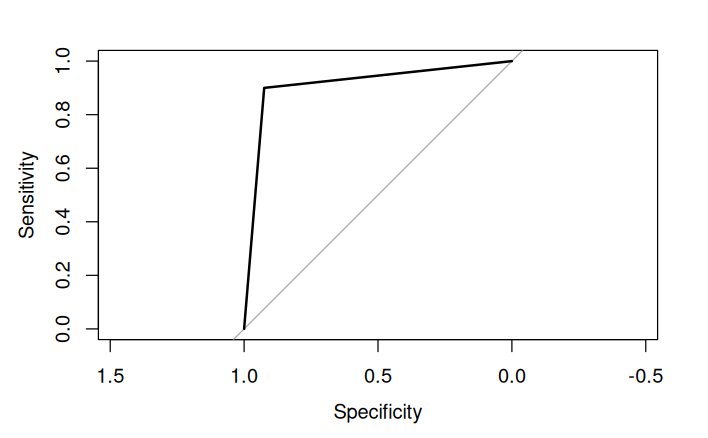

```r
# Predicciones del modelo de entretamiento
glm_entrenamiento <- predict(glm$finalModel, cbind(entrenamiento_en_x, entrenamiento_en_y), type = "response")

# determinacion de la curva ROC
umbral <- 0.5
pred_ent <- ifelse(glm_entrenamiento >= umbral, 1, 0)
curvaROC_ent <- roc(entrenamiento_en_y, pred_ent)
plot(curvaROC_ent)
```

```r
# Matriz de confusion
matrizConf <- confusionMatrix(as.factor(entrenamiento_en_y), as.factor(pred_ent))
print(matrizConf)
```

```
Confusion Matrix and Statistics

          Reference
Prediction  0  1
         0 37  3
         1  4 36

               Accuracy : 0.9125
                 95% CI : (0.828, 0.9641)
    No Information Rate : 0.5125
    P-Value [Acc > NIR] : 1.48e-14

                  Kappa : 0.825

 Mcnemar's Test P-Value : 1

            Sensitivity : 0.9024
            Specificity : 0.9231
         Pos Pred Value : 0.9250
         Neg Pred Value : 0.9000
             Prevalence : 0.5125
         Detection Rate : 0.4625
   Detection Prevalence : 0.5000
      Balanced Accuracy : 0.9128

       'Positive' Class : 0
```

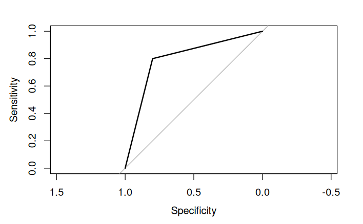

```r
# Predicciones del modelo de prueba
glm_prueba <- predict(glm$finalModel, cbind(prueba_en_x, prueba_en_y), type = "response")

# determinacion de la curva ROC
umbral <- 0.5
pred_prueba <- ifelse(glm_prueba >= umbral, 1, 0)
curvaROC_prueba <- roc(prueba_en_y, pred_prueba)
plot(curvaROC_prueba)
```

```r
# Matriz de confusion
matrizConfPrueba <- confusionMatrix(as.factor(prueba_en_y), as.factor(pred_prueba))
print(matrizConfPrueba)
```

```
Confusion Matrix and Statistics

          Reference
Prediction 0 1
         0 8 2
         1 2 8

               Accuracy : 0.8
                 95% CI : (0.5634, 0.9427)
    No Information Rate : 0.5
    P-Value [Acc > NIR] : 0.005909

                  Kappa : 0.6

 Mcnemar's Test P-Value : 1.000000

            Sensitivity : 0.8
            Specificity : 0.8
         Pos Pred Value : 0.8
         Neg Pred Value : 0.8
             Prevalence : 0.5
         Detection Rate : 0.4
   Detection Prevalence : 0.5
      Balanced Accuracy : 0.8

       'Positive' Class : 0
```

6. Pronunciarse sobre la confiabilidad y el poder predictivo de los modelos obtenidos.

```r
# Modelo de regresión lineal múltiple influencia de los residuos
obs_modelo_Weight <- data.frame(predicted.probabilities = fitted(rlm$finalModel))
obs_modelo_Weight [["residuos_estandarizados"]] <- rstandard(rlm$finalModel )
obs_modelo_Weight [["residuos_estudiantizados"]] <- rstudent(rlm$finalModel )
obs_modelo_Weight [["distancia_Cook"]] <- cooks.distance (rlm$finalModel)
obs_modelo_Weight [["dfbeta"]] <- dfbeta(rlm$finalModel)
obs_modelo_Weight [["dffit"]] <- dffits(rlm$finalModel)
obs_modelo_Weight [["apalancamiento"]] <- hatvalues (rlm$finalModel)
obs_modelo_Weight [["covratio"]] <- covratio (rlm$finalModel)

cat("Identificación de valores atípicos: \n")
```

```
Identificación de valores atípicos:
```

```r
# Observaciones con residuos estandarizados fuera del 95% esperado.
sospechosos1 <- which(abs(obs_modelo_Weight [["residuos_estandarizados"]]) > 1.96)

cat("-Residuos estandarizados fuera del 95% esperado:", sospechosos1, "\n")
```

```
-Residuos estandarizados fuera del 95% esperado: 8 10 21 38
```

```r
# Observaciones con distancia de Cook mayor a uno.
sospechosos2 <- which(obs_modelo_Weight [["cooks.distance"]] > 1)

cat("-Residuos con una distancia de Cook alta:", sospechosos2, "\n")
```

```
-Residuos con una distancia de Cook alta:
```

```r
# Observaciones con apalancamiento mayor igual al doble del apalancamiento promedio.

apal_medio <- (ncol(muestra_rlm) + 1) / nrow(muestra_rlm)
sospechosos3 <- which(obs_modelo_Weight[["apalancamiento"]] > 2 * apal_medio)

cat("-Residuos con apalancamiento fuera de rango:", sospechosos3, "\n")
```

```
-Residuos con apalancamiento fuera de rango:
```

```r
# Observaciones con DFBeta mayor o igual a.
sospechosos4 <- which(apply (obs_modelo_Weight [["dfbeta"]] >= 1, 1, any))
names (sospechosos4) <- NULL

cat("-Residuos con DFBeta >= 1:", sospechosos4, "\n")
```

```
-Residuos con DFBeta >= 1: 29 47 76 91
```

```r
# Observaciones con razones de covarianza fuera del rango.
inferior <- 1 - 3 * apal_medio
superior <- 1 + 3 * apal_medio
sospechosos5 <- which(obs_modelo_Weight [["covratio"]] < inferior | obs_modelo_Weight [["covratio"]] > superior)

cat("-Residuos con razón de covarianza fuera del rango:", sospechosos5, "\n")
```

```
-Residuos con razón de covarianza fuera del rango:
```

```r
# Resumen de los valores atípicos.
sospechosos <- c(sospechosos1, sospechosos2, sospechosos3, sospechosos4, sospechosos5)

cat("Resumen de los valores atípicos:", sospechosos, "\n")
```

```
Resumen de los valores atípicos: 8 10 21 38 29 47 76 91
```

```r
cat("Apalancamiento promedio:", apal_medio, "\n")
```

```
Apalancamiento promedio: 0.26
```

```r
cat("Intervalo razón de covarianza: [", inferior, ",", superior, "]\n")
```

```
Intervalo razón de covarianza: [ 0.22 , 1.78 ]
```

```r
print(round(obs_modelo_Weight[sospechosos, c("distancia_Cook", "apalancamiento", "covratio")], 3))
```

|  | distancia_Cook | apalancamiento | covratio |
| --- | --- | --- | --- |
| X8 | 0.194 | 0.102 | 0.335 |
| X10 | 0.022 | 0.034 | 0.718 |
| X21 | 0.050 | 0.090 | 0.838 |
| X38 | 0.165 | 0.171 | 0.738 |
| X29 | 0.009 | 0.080 | 1.100 |
| X47 | 0.014 | 0.104 | 1.118 |
| X76 | 0.011 | 0.057 | 1.020 |
| X91 | 0.012 | 0.110 | 1.146 |

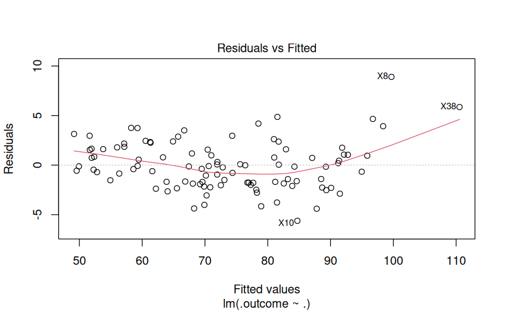

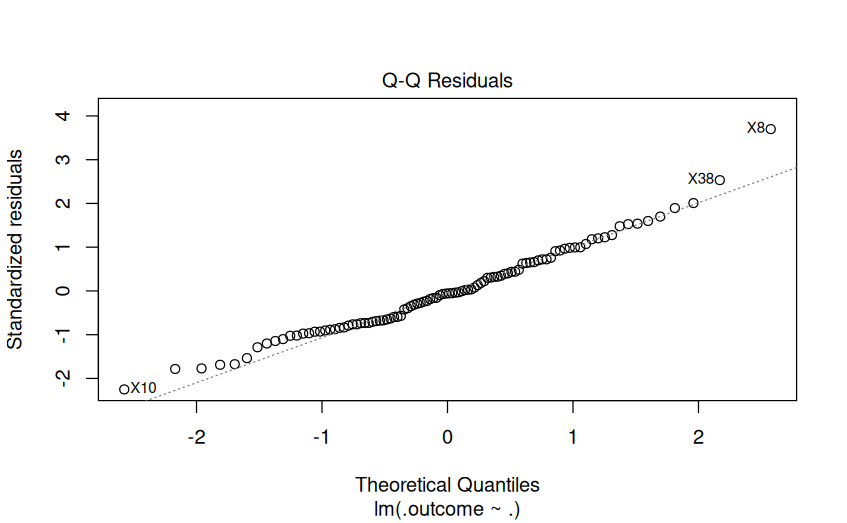

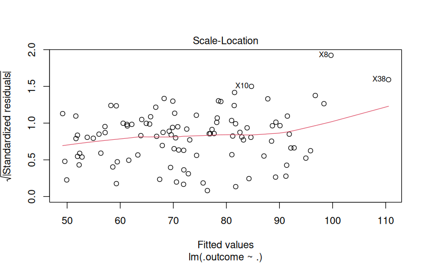

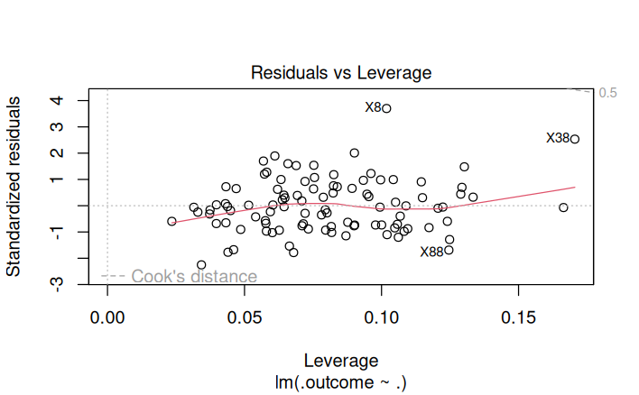

```r
plot(rlm$finalModel)
```

```r
# ------------ CONDICIONES -------------------------------
modelo <- rlm$finalModel
# Comprobar independencia de los residuos
cat ( " Prueba de Durbin - Watson para autocorrelaciones " )
```

```
 Prueba de Durbin - Watson para autocorrelaciones
```

```r
cat ( " entre errores :\n " )
```

```
 entre errores :
```

```r
print ( durbinWatsonTest ( modelo ) )
```

```
 lag Autocorrelation D-W Statistic p-value
   1      -0.1351703      2.244343   0.242
 Alternative hypothesis: rho != 0
```

```r
# Comprobar normalidad de los residuos .
cat ( " \ nPrueba de normalidad para los residuos :\n " )
```

```
  nPrueba de normalidad para los residuos :
```

```r
print ( shapiro.test(modelo$residuals))
```

```
    Shapiro-Wilk normality test

data:  modelo$residuals
W = 0.97793, p-value = 0.09159
```

```r
# Comprobar homocedasticidad de los residuos .
cat ( " Prueba de homocedasticidad para los residuos :\n " )
```

```
 Prueba de homocedasticidad para los residuos :
```

```r
print ( ncvTest ( modelo ) )
```

```
Non-constant Variance Score Test
Variance formula: ~ fitted.values
Chisquare = 14.94356, Df = 1, p = 0.00011078
```

```r
# Comprobar la multicolinealidad .
vifs <- vif ( modelo )
cat ( " \ nVerificar la multicolinealidad :\n" )
```

```
  nVerificar la multicolinealidad :
```

```r
cat ( " - VIFs :\n " )
```

```
 - VIFs :
```

```r
print ( vifs )
```

```
  Biiliac.diameter     Shoulder.Girth        Chest.Girth        Waist.Girth
          1.851791           7.723988          11.605514           6.255226
       Thigh.Girth Calf.Maximum.Girth             Height
          2.175488           2.406917           1.812749
```

```r
cat ( " - Tolerancias :\n" )
```

```
 - Tolerancias :
```

```r
print (1 / vifs )
```

```
  Biiliac.diameter     Shoulder.Girth        Chest.Girth        Waist.Girth
        0.54001788         0.12946679         0.08616594         0.15986634
       Thigh.Girth Calf.Maximum.Girth             Height
        0.45966690         0.41546922         0.55164828
```

```r
cat ( "-VIF medio: " , mean ( vifs ) , " \n" )
```

```
-VIF medio:  4.833096
```

Al revisar la distancia de Cook y que en esta no haya valores preocupantes, es decir, no es preocupante.

En resumen, se llevaron a cabo diferentes pruebas para evaluar ciertas condiciones en el estudio. Estos son los resultados:

Normalidad: Para verificar si los datos siguen una distribución normal, se utilizó un valor de p. Como el valor de p es mayor a 0.05, se considera que se cumple la condición de normalidad.

Independencia: Se realizó un test de independencia entre los residuos. Un valor cercano a 2 indica que los residuos son independientes entre sí.

Homocedasticidad: Se llevó a cabo un test de homocedasticidad para evaluar si los errores de la regresión tienen una varianza constante. Un valor de p menor a 0.05 indica que la suposición de homocedasticidad no se cumple. Adicionalmente, una forma de poder corregir la homocedasticidad es transformando la escala de la variable de respuesta. Por ejemplo, cambiar a escala logarítmica.

Multicolinealidad: Se examinó la presencia de multicolinealidad, que es cuando existe una alta correlación entre las variables predictoras. Se observó que la variable “Chest.Girth” tiene un VIF (Factor de Inflación de la Varianza) igual o mayor a 10, lo cual es motivo de preocupación, ya que indica una posible multicolinealidad.

Tolerancia: Se analizó la tolerancia de las variables, que es el inverso del VIF. Los valores problemáticos son aquellos que son menores a 0.2. En este caso, se identificaron las variables “Shoulder.Girth”, “Chest.Girth” y “Waist.Girth” como problemáticas en términos de tolerancia.

```r
# Modelo RFE
obs_modelo_IMC <- data.frame(predicted.probabilities = fitted(modelo_imc$fit))
obs_modelo_IMC [["residuos_estandarizados"]] <- rstandard(modelo_imc$fit )
obs_modelo_IMC [["residuos_estudiantizados"]] <- rstudent(modelo_imc$fit )
obs_modelo_IMC [["distancia_Cook"]] <- cooks.distance (modelo_imc$fit)
obs_modelo_IMC [["dfbeta"]] <- dfbeta(modelo_imc$fit)
obs_modelo_IMC [["dffit"]] <- dffits(modelo_imc$fit)
obs_modelo_IMC [["apalancamiento"]] <- hatvalues (modelo_imc$fit)
obs_modelo_IMC [["covratio"]] <- covratio (modelo_imc$fit)

cat("Identificación de valores atípicos: \n")
```

```
Identificación de valores atípicos:
```

```r
# Observaciones con residuos estandarizados fuera del 95% esperado.
sospechosos1 <- which(abs(obs_modelo_IMC [["residuos_estandarizados"]]) > 1.96)

cat("-Residuos estandarizados fuera del 95% esperado:", sospechosos1, "\n")
```

```
-Residuos estandarizados fuera del 95% esperado: 7 26 34 49 51 79
```

```r
# Observaciones con distancia de Cook mayor a uno.
sospechosos2 <- which(obs_modelo_IMC [["cooks.distance"]] > 1)

cat("-Residuos con una distancia de Cook alta:", sospechosos2, "\n")
```

```
-Residuos con una distancia de Cook alta:
```

```r
# Observaciones con apalancamiento mayor igual al doble del apalancamiento promedio.

apal_medio <- (ncol(muestra_imc) + 1) / nrow(muestra_imc)
sospechosos3 <- which(obs_modelo_IMC[["apalancamiento"]] > 2 * apal_medio)

cat("-Residuos con apalancamiento fuera de rango:", sospechosos3, "\n")
```

```
-Residuos con apalancamiento fuera de rango:
```

```r
# Observaciones con DFBeta mayor o igual a.
sospechosos4 <- which(apply (obs_modelo_IMC [["dfbeta"]] >= 1, 1, any))
names (sospechosos4) <- NULL

cat("-Residuos con DFBeta >= 1:", sospechosos4, "\n")
```

```
-Residuos con DFBeta >= 1: 26 34 51 79
```

```r
# Observaciones con razones de covarianza fuera del rango.
inferior <- 1 - 3 * apal_medio
superior <- 1 + 3 * apal_medio
sospechosos5 <- which(obs_modelo_IMC [["covratio"]] < inferior | obs_modelo_IMC [["covratio"]] > superior)

cat("-Residuos con razón de covarianza fuera del rango:", sospechosos5, "\n")
```

```
-Residuos con razón de covarianza fuera del rango: 2 6 10 13 16 17 18 19 24 25 27 28 31 35 38 39 47 48 49 50 57 59 62 66 67 68 78
```

```r
# Resumen de los valores atípicos.
sospechosos <- c(sospechosos1, sospechosos2, sospechosos3, sospechosos4, sospechosos5)

cat("Resumen de los valores atípicos:", sospechosos, "\n")
```

```
Resumen de los valores atípicos: 7 26 34 49 51 79 26 34 51 79 2 6 10 13 16 17 18 19 24 25 27 28 31 35 38 39 47 48 49 50 57 59 62 66 67 68 78
```

```r
cat("Apalancamiento promedio:", apal_medio, "\n")
```

```
Apalancamiento promedio: 0.25
```

```r
cat("Intervalo razón de covarianza: [", inferior, ",", superior, "]\n")
```

```
Intervalo razón de covarianza: [ 0.25 , 1.75 ]
```

```r
print(round(obs_modelo_IMC[sospechosos, c("distancia_Cook", "apalancamiento", "covratio")], 3))
```

|  | distancia_Cook | apalancamiento | covratio |
| --- | --- | --- | --- |
| 80 | 0.087 | 0.257 | 0.327 |
| 18 | 0.085 | 0.272 | 0.396 |
| 19 | 0.073 | 0.264 | 0.466 |
| 12 | 0.059 | 0.169 | 0.220 |
| 47 | 0.120 | 0.337 | 0.410 |
| 91 | 0.125 | 0.326 | 0.342 |
| 18.1 | 0.085 | 0.272 | 0.396 |
| 19.1 | 0.073 | 0.264 | 0.466 |
| 47.1 | 0.120 | 0.337 | 0.410 |
| 91.1 | 0.125 | 0.326 | 0.342 |

[output cut: 27 more lines]

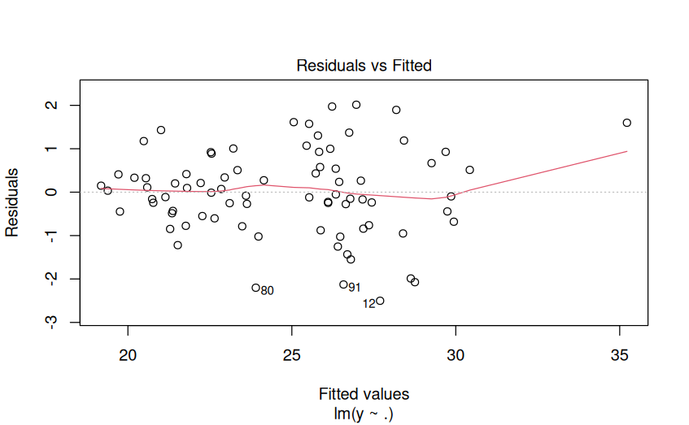

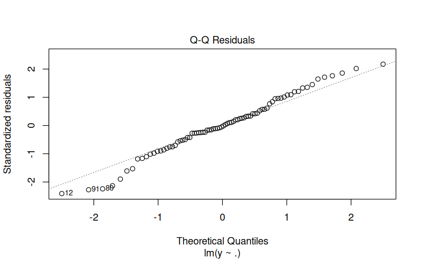

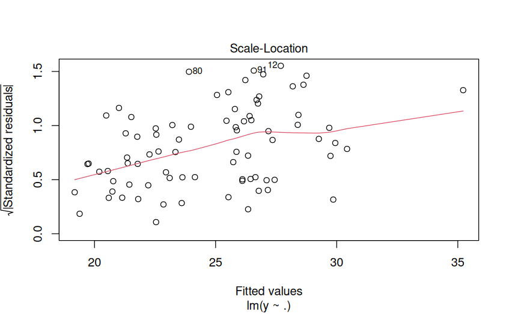

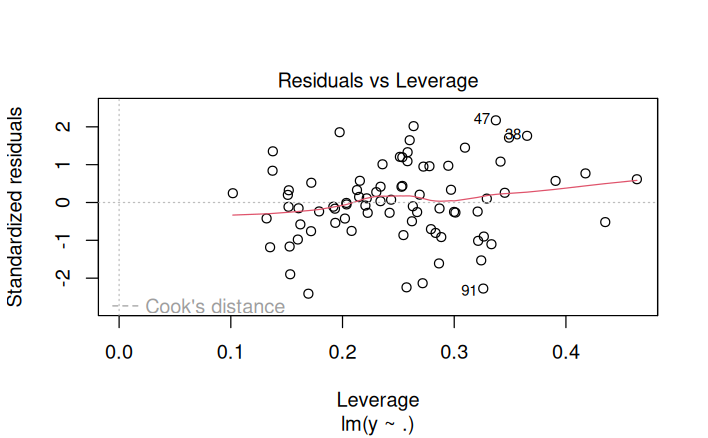

```r
plot(modelo_imc$fit)
```

```r
# ------------ CONDICIONES -------------------------------
modelo <- modelo_imc$fit
# Comprobar independencia de los residuos
cat ( " Prueba de Durbin - Watson para autocorrelaciones " )
```

```
 Prueba de Durbin - Watson para autocorrelaciones
```

```r
cat ( " entre errores :\n " )
```

```
 entre errores :
```

```r
print ( durbinWatsonTest ( modelo ) )
```

```
 lag Autocorrelation D-W Statistic p-value
   1      0.03937984       1.91128   0.694
 Alternative hypothesis: rho != 0
```

```r
# Comprobar normalidad de los residuos .
cat ( " \ nPrueba de normalidad para los residuos :\n " )
```

```
  nPrueba de normalidad para los residuos :
```

```r
print ( shapiro.test(modelo$residuals))
```

```
    Shapiro-Wilk normality test

data:  modelo$residuals
W = 0.98387, p-value = 0.4119
```

```r
# Comprobar homocedasticidad de los residuos .
cat ( " Prueba de homocedasticidad para los residuos :\n " )
```

```
 Prueba de homocedasticidad para los residuos :
```

```r
print ( ncvTest ( modelo ) )
```

```
Non-constant Variance Score Test
Variance formula: ~ fitted.values
Chisquare = 9.168812, Df = 1, p = 0.0024617
```

```r
# Comprobar la multicolinealidad .
vifs <- vif ( modelo )
cat ( " \ nVerificar la multicolinealidad :\n" )
```

```
  nVerificar la multicolinealidad :
```

```r
cat ( " - VIFs :\n " )
```

```
 - VIFs :
```

```r
print ( vifs )
```

```
                 Gender           Forearm.Girth         Ankles.diameter
               8.007583               23.100898                6.237910
        Wrists.diameter          Knees.diameter         Elbows.diameter
               6.578317                3.131908               12.044865
    Wrist.Minimum.Girth     Biacromial.diameter              Knee.Girth
              11.131748                5.192620                5.470120
     Calf.Maximum.Girth        Biiliac.diameter             Bicep.Girth
               4.200725                3.077847               13.273117
    Ankle.Minimum.Girth          Shoulder.Girth             Thigh.Girth
               4.875712               11.628457                4.646940
         Chest.diameter             Waist.Girth             Chest.depth
               6.875269                8.350978                4.620450
Bitrochanteric.diameter
               3.728491
```

```r
cat ( " - Tolerancias :\n" )
```

```
 - Tolerancias :
```

```r
print (1 / vifs )
```

```
                 Gender           Forearm.Girth         Ankles.diameter
             0.12488162              0.04328836              0.16031009
        Wrists.diameter          Knees.diameter         Elbows.diameter
             0.15201456              0.31929420              0.08302293
    Wrist.Minimum.Girth     Biacromial.diameter              Knee.Girth
             0.08983315              0.19258103              0.18281133
     Calf.Maximum.Girth        Biiliac.diameter             Bicep.Girth
             0.23805412              0.32490244              0.07534025
    Ankle.Minimum.Girth          Shoulder.Girth             Thigh.Girth
             0.20509823              0.08599593              0.21519537
         Chest.diameter             Waist.Girth             Chest.depth
             0.14544885              0.11974645              0.21642912
Bitrochanteric.diameter
             0.26820505
```

```r
cat ( " - VIF medio : " , mean ( vifs ) , " \n" )
```

```
 - VIF medio :  7.693366
```

Al revisar la distancia de Cook y que en esta no hayan residuos preocupantes, es decir, no existen residuos con una distancia cercana o mayor a 1.

Después de realizar las pruebas para verificar las condiciones, hemos obtenido las siguientes conclusiones:

Normalidad: Para evaluar la normalidad de los datos, utilizamos el valor de p. Como el valor de p es mayor a 0.05, se considera que se cumple la condición de normalidad.

Independencia de residuos: Al realizar el test de independencia entre los residuos, obtuvimos un valor cercano a 2, lo que indica que los residuos son independientes entre sí.

Homocedasticidad: Sin embargo, al llevar a cabo el test de homocedasticidad, obtuvimos un valor de p menor a 0.05, lo que indica que no se cumple la suposición de homocedasticidad. Esto implica que la varianza de los errores de la regresión no es constante. También se puede observar en el gráfico Residuals vs Fitted que los residuos no siguen una homocedasticidad y están muy dispersos entre sí. Adicionalmente, una forma de poder corregir la homocedasticidad es transformando la escala de la variable de respuesta. Por ejemplo, cambiar a escala logarítmica.

Tolerancia: Al evaluar la tolerancia, identificamos los siguientes valores preocupantes (menores a 0.2): Gender, Forearm.Girth, Ankles.diameter, Wrists.diameter, Elbows.diameter, Wrist.Minimum.Girth, Biacromial.diameter, Knee.Girth, Bicep.Girth, Shoulder.Girth, Chest.diameter y Waist.Girth. Estos valores indican un posible problema de multicolinealidad y sugieren que estas variables no contribuyen de manera significativa al modelo.

En conclusión, tenemos un modelo que puede ser generalizable (visto anteriormente en los cálculos del RMSE entre la predicción en entrenamiento y en prueba), pero en confiabilidad el modelo decae debido a algunas variables predictoras que presentan un VIF mayor que 10, lo cual nos plantea un problema con respecto a las estimaciones del modelo, al igual que la falta de homocedasticidad, donde el valor de p fue menor a 0.05, lo cual reduce la eficacia de las estimaciones. Por lo tanto, el modelo no presenta la confiabilidad suficiente para realizar estimaciones correctas, a pesar de tener un bajo RMSE entre ambas predicciones.

```r
# Modelo de regresión Logística.

# Independencia de los residuos.
cat("Verificación de independencia de los residuos\n")
```

```
Verificación de independencia de los residuos
```

```r
cat("-----------------------------------------------\n")
print(durbinWatsonTest(glm$finalModel, max.lag = 5))
```

```
 lag Autocorrelation D-W Statistic p-value
   1     -0.19291995      2.385832   0.050
   2      0.05688789      1.883713   0.874
   3     -0.03982507      2.077077   0.398
   4     -0.06606263      2.129367   0.318
   5      0.06765318      1.857085   0.768
 Alternative hypothesis: rho[lag] != 0
```

```r
# Detectar posibles valores atípicos.
cat("Identificación de posibles valores atípicos\n")
```

```
Identificación de posibles valores atípicos
```

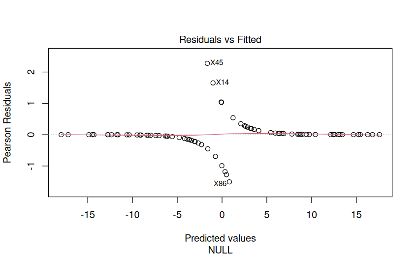

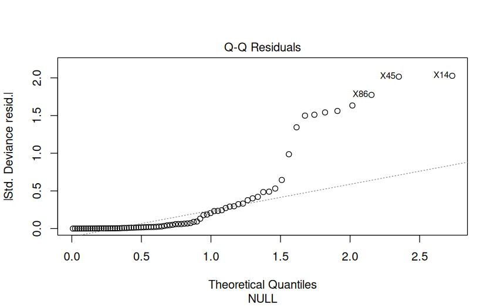

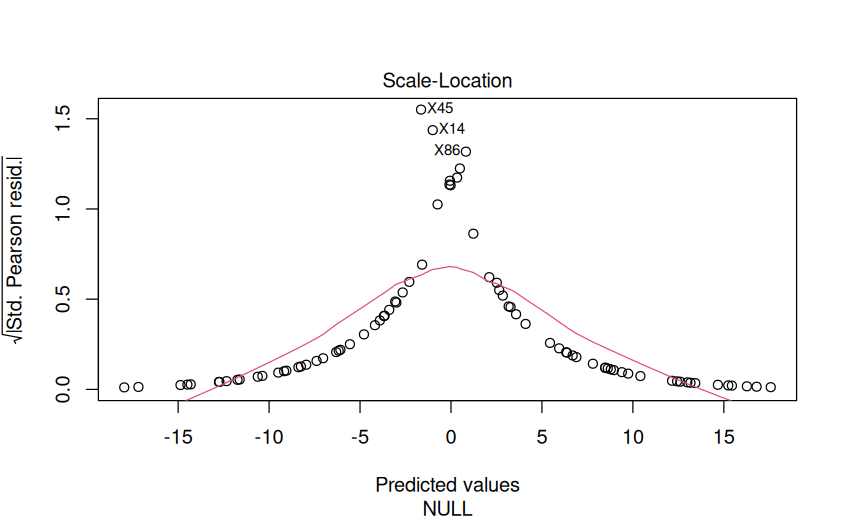

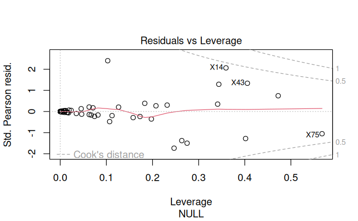

```r
cat("----------------------------------------------\n")
plot(glm$finalModel)
```

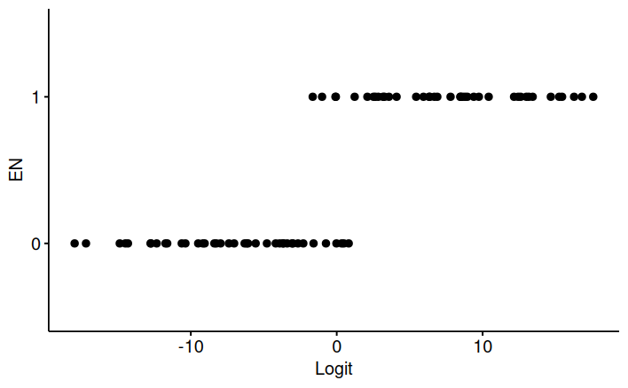

```r
# Ahora verifiquemos el supuesto de linealidad de la relación
 xs1 <- data.frame(Logit = log(fitted(glm$finalModel)/(1-fitted(glm$finalModel))),
                  EN = entrenamiento_en_y)
 pxs1 <- ggscatter(data = xs1, x = "Logit", y = "EN", conf.int = TRUE)
 print(pxs1)
```

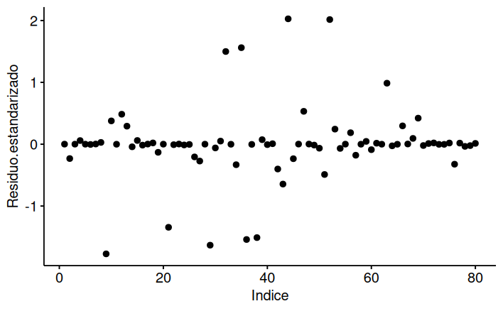

```r
# Revisemos ahora los residuos y si cumplen las condiciones necesarias
 xs2 <- data.frame(Indice = 1:nrow(entrenamiento_en_x),
                  Residuo.estandarizado = rstandard(glm$finalModel))
 pxs2 <- ggscatter(data = xs2, x = "Indice", y = "Residuo.estandarizado")
 print(pxs2)
```

```r
 # Normalidad
 print(shapiro.test(resid(glm$finalModel)))
```

```
    Shapiro-Wilk normality test

data:  resid(glm$finalModel)
W = 0.74904, p-value = 2.234e-10
```

```r
 # Homocedasticidad
 print(bptest(glm$finalModel))
```

```
    studentized Breusch-Pagan test

data:  glm$finalModel
BP = 3.8738, df = 5, p-value = 0.5677
```

```r
# Obtener los residuos y las estadísticas.
obs_modelo_EN <- data.frame(predicted.probabilities = fitted(glm$finalModel))
obs_modelo_EN[["standardized.residuals"]] <- rstandard(glm$finalModel)
obs_modelo_EN[["studentized.residuals"]] <- rstudent(glm$finalModel)
obs_modelo_EN[["cooks.distance"]] <- cooks.distance(glm$finalModel)
obs_modelo_EN[["dfbeta"]] <- dfbeta(glm$finalModel)
obs_modelo_EN[["dffit"]] <- dffits(glm$finalModel)
obs_modelo_EN[["leverage"]] <- hatvalues(glm$finalModel)
obs_modelo_EN[["covratio"]] <- covratio (glm$finalModel)
dfEN <- data.frame(obs_modelo_EN)

# Evaluar residuos estandarizados que escapen a la normalidad.
# 95% de los residuos estandarizados deberían estar entre
# -1.96 y 1.96, y 99% entre -2.58 y 2.58.
sospechosos1 <- which(abs(obs_modelo_EN[["standardized.residuals"]]) > 1.96)
sospechosos1 <- sort(sospechosos1)
cat("\n\n")
```

```r
cat("Residuos estandarizados fuera del 95% esperado\n")
```

```
Residuos estandarizados fuera del 95% esperado
```

```r
cat("------------------------------------------------\n")
print(rownames(entrenamiento_glm[sospechosos1, ]))
```

```
[1] "14" "45"
```

```r
# Revisar casos con distancia de Cook mayor a uno.
sospechosos2 <- which(obs_modelo_EN[["cooks.distance"]] > 1)
sospechosos2 <- sort(sospechosos2)
cat("\n\n")
```

```r
cat("Residuales con una distancia de Cook alta\n")
```

```
Residuales con una distancia de Cook alta
```

```r
cat("-----------------------------------------\n")
print(rownames(entrenamiento_glm[sospechosos2, ]))
```

```
character(0)
```

```r
# Revisar casos cuyo apalancamiento sea más del doble
# o triple del apalancamiento promedio.
leverage.promedio <- ncol(entrenamiento_glm) / nrow(entrenamiento_glm)
sospechosos3 <- which(obs_modelo_EN[["leverage"]] > leverage.promedio)
sospechosos3 <- sort(sospechosos3)
cat("\n\n")
```

```r
cat("Residuales con levarage fuera de rango (>")
```

```
Residuales con levarage fuera de rango (>
```

```r
cat(round(leverage.promedio, 3), ") ", "\n", sep = " ")
```

```
0.075 )
```

```r
cat("----------------------------------------------\n")
print(rownames(entrenamiento_glm[sospechosos3, ]))
```

```
 [1] "66" "86" "23" "7"  "36" "75" "71" "91" "21" "70" "43" "68" "61" "64" "80" "14"
[17] "19" "87" "45" "20" "9"
```

```r
# Revisar casos con DFBeta >= 1.
sospechosos4 <- which(apply(obs_modelo_EN[["dfbeta"]] >= 1 , 1 , any ))
sospechosos4 <- sort ( sospechosos4 )
names ( sospechosos4 ) <- NULL
cat ( " \n\n " )
```

```r
cat ( " Residuales con DFBeta sobre 1\n " )
```

```
 Residuales con DFBeta sobre 1
```

```r
cat ( " - - - - - - - - - - - - - - - - - - - - - - - - - - - - -\n " )
print (rownames(entrenamiento_glm[ sospechosos4 , ]))
```

```
[1] "86" "75" "91" "21" "43" "68" "14" "45"
```

```r
# Detalle de las observaciones posiblemente atípicas .
sospechosos <- c ( sospechosos1 , sospechosos2 , sospechosos3 , sospechosos4 )
sospechosos <- sort(unique( sospechosos) )
```

```r
print(sospechosos)
```

```
 [1]  2  9 10 12 13 21 27 29 32 34 35 36 38 42 43 44 47 51 52 63 69
```

```r
cat ( " \n\n" )
```

```r
cat ( " Casos sospechosos \n " )
```

```
 Casos sospechosos
```

```r
cat ( " - - - - - - - - - - - - - - - - -\n " )
#print (entrenamiento_glm[sospechosos , ])
cat ( " \n\n " )
```

```r
print(round(dfEN[sospechosos, c("cooks.distance", "leverage", "covratio")], 3))
```

|  | cooks.distance | leverage | covratio |
| --- | --- | --- | --- |
| X66 | 0.000 | 0.082 | 1.163 |
| X86 | 0.165 | 0.247 | 0.516 |
| X23 | 0.003 | 0.207 | 1.312 |
| X7 | 0.011 | 0.341 | 1.534 |
| X36 | 0.001 | 0.126 | 1.211 |
| X75 | 0.242 | 0.567 | 1.421 |
| X71 | 0.001 | 0.112 | 1.195 |
| X91 | 0.142 | 0.275 | 0.634 |
| X21 | 0.145 | 0.344 | 0.809 |
| X70 | 0.002 | 0.173 | 1.269 |

[output cut: 11 more lines]

```r
NA
```

Si bien hay algunas observaciones que podrían considerarse atípicas, al revisar residuos preocupantes, ninguno presenta un valor cercano a 1 respecto a la distancia de Cook, por lo que podemos descartar la idea de que existen residuos problemáticos. De igual manera, se puede observar que existen algunos residuos preocupantes con DFBeta sobre 1, y también residuos con apalancamientos sobre el promedio. En este apartado, podemos observar que hay al menos 5 residuos que sobrepasan por mucho el triple del apalancamiento promedio, como el residuo X75 que posee un apalancamiento de 0.567.

Para el análisis de linealidad de los residuos, se observa el gráfico de residuos estandarizados, donde podemos notar que varios residuos se alejan de la normalidad (no deben alejarse de y = 0). Para complementar la idea, se realiza el cálculo del test de Shapiro para verificar si existe normalidad, e igualmente el test de Breusch-Pagan para la homocedasticidad. En el caso del test de Shapiro-Wilk, podemos observar que no existe normalidad (p < 0.05), pero sí existe homocedasticidad (p > 0.05) para el test de Breusch-Pagan. Por lo tanto, podemos concluir que existe linealidad en los residuos, pero debemos tener precaución debido a que el test de Shapiro arrojó un valor de p < 0.05.

Por último, como se analizó anteriormente con el poder predictivo del modelo logístico, podemos concluir que el modelo no es confiable, incluso si se cumplieron la mayoría de las condiciones. Sin embargo, no podemos pasar por alto el apalancamiento que las variables agregan al modelo. Si se desea mejorar la confiabilidad del modelo, se deberían explorar técnicas para reducir el apalancamiento, o en su defecto, eliminar la variable (aunque debería existir una buena razón para optar por esta opción).

# Bibliografia

https://rdrr.io/cran/caret/man/rfeControl.html  
https://topepo.github.io/caret/recursive-feature-elimination.html https://stackoverflow.com/questions/52950003/retrieve-selected-variables-from-caret-recursive-feature-elimination-rfe-resul https://stackoverflow.com/questions/12481365/access-all-models-produced-by-rfe-in-caret